# DA5020 – Assignment 5

```r
library(tidyverse)
library(httr)
library(XML)
```

## Question 1 – 12.6.1 Exercises

1. In this case study I set values_drop_na = TRUE just to make it easier to check that we had the correct values. Is this reasonable? Think about how missing values are represented in this dataset. Are there implicit missing values? What’s the difference between an NA and zero?

Implicit missing values in this dataset are likely represented by counts of 0 which may not necessarily represent 0 reported cases, but instead represents an unknown amount of reported cases.

2. What happens if you neglect the `mutate()` step? (`mutate(names_from = stringr::str_replace(key, "newrel", "new_rel"))`)

If the `mutate()` step is neglected, the `separate()` function will fail because the underscore is missing which is needed needed to identify cases that are new and relapse.

3. I claimed that iso2 and iso3 were redundant with country. Confirm this claim.

```r
library(countrycode)
who_country <-
  who %>%
      select(country, iso2, iso3) %>%
      distinct() %>%
    mutate(
      iso2_to_name = countrycode(
        sourcevar   = iso2,
        origin      = "iso2c",
        destination = "country.name"),
      iso3_to_name = countrycode(
        sourcevar   = iso3,
        origin      = "iso3c",
        destination = "country.name")) %>%                        ## convert iso2 and iso3 to full name
    mutate(
      name_is_iso2_is_iso3 = isTRUE(
        country == iso2_to_name && country == iso3_to_name))      ## check if converted names match original
```

```
Some values were not matched unambiguously: AN, YU
Some values were not matched unambiguously: ANT, SCG
```

```r
who_country
```

| country | iso2 | iso3 | iso2_to_name | iso3_to_name | name_is_iso2_is_iso3 |
| --- | --- | --- | --- | --- | --- |
| Afghanistan | AF | AFG | Afghanistan | Afghanistan | TRUE |
| Albania | AL | ALB | Albania | Albania | TRUE |
| Algeria | DZ | DZA | Algeria | Algeria | TRUE |
| American Samoa | AS | ASM | American Samoa | American Samoa | TRUE |
| Andorra | AD | AND | Andorra | Andorra | TRUE |
| Angola | AO | AGO | Angola | Angola | TRUE |
| Anguilla | AI | AIA | Anguilla | Anguilla | TRUE |
| Antigua and Barbuda | AG | ATG | Antigua & Barbuda | Antigua & Barbuda | TRUE |
| Argentina | AR | ARG | Argentina | Argentina | TRUE |
| Armenia | AM | ARM | Armenia | Armenia | TRUE |

[output cut: 209 more lines]

```r
who_country %>%
    pull(name_is_iso2_is_iso3) %>% unique()                       ## is it all true?
```

```
[1] TRUE
```

```r
who_country %>% filter(iso2 %in% c("AN", "YU")) ## it's all true except for two which couldn't be converted
```

| country | iso2 | iso3 | iso2_to_name | iso3_to_name | name_is_iso2_is_iso3 |
| --- | --- | --- | --- | --- | --- |
| Netherlands Antilles | AN | ANT | NA | NA | TRUE |
| Serbia & Montenegro | YU | SCG | NA | NA | TRUE |

4. For each country, year, and sex compute the total number of cases of TB. Make an informative visualisation of the data.

```r
who1 <-
  who %>%
  pivot_longer(
    cols = new_sp_m014:newrel_f65,
    names_to = "key",
    values_to = "cases",
    values_drop_na = TRUE) %>%
  mutate(
    key = stringr::str_replace(key, "newrel", "new_rel")) %>%
  separate(key, c("new", "var", "sexage")) %>%
  select(-new, -iso2, -iso3) %>%
  separate(sexage, c("sex", "age"), sep = 1) %>%
  select(-one_of(c("var", "age"))) %>%
  group_by_at(c("country", "year", "sex")) %>%
  summarise(total_sex = sum(cases)) %>%
  ungroup %>% group_by(country) %>%
  mutate(total_country = sum(total_sex)) %>% ungroup() %>%
  filter(total_country >= 100000) ## only consider countries with >= 1000,000 cases
                                  ## otherwise, the chart is too large

  who1
```

| country | year | sex | total_sex | total_country |
| --- | --- | --- | --- | --- |
| Afghanistan | 1997 | f | 102 | 140225 |
| Afghanistan | 1997 | m | 26 | 140225 |
| Afghanistan | 1998 | f | 1207 | 140225 |
| Afghanistan | 1998 | m | 571 | 140225 |
| Afghanistan | 1999 | f | 517 | 140225 |
| Afghanistan | 1999 | m | 228 | 140225 |
| Afghanistan | 2000 | f | 1751 | 140225 |
| Afghanistan | 2000 | m | 915 | 140225 |
| Afghanistan | 2001 | f | 3062 | 140225 |
| Afghanistan | 2001 | m | 1577 | 140225 |

[output cut: 990 more lines]

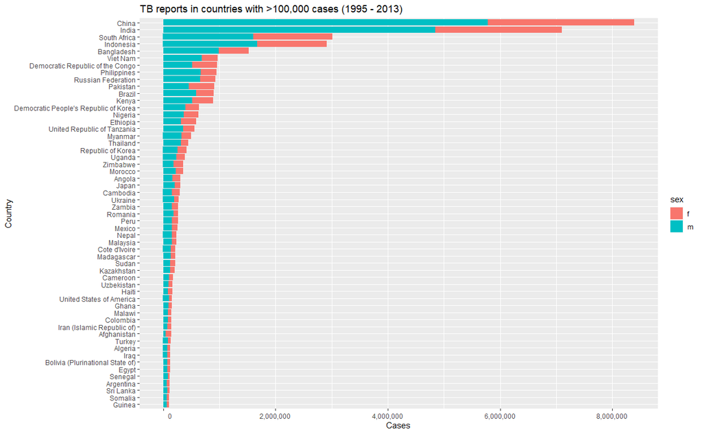

```r
  ggplot(data = who1,
         aes(x = reorder(country, total_country),
             y = total_sex)) +
  geom_col(aes(fill = sex)) +
  coord_flip() +
  scale_y_continuous(labels = function(x) format(x, scientific = FALSE, big.mark = ",")) +
  labs(title = "TB reports in countries with >100,000 cases (1995 - 2013)",
       x     = "Country",
       y     = "Cases")
```

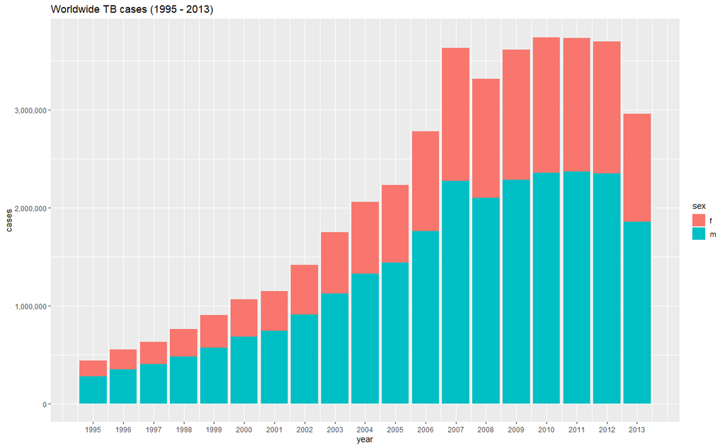

```r
  ## males appear to be disproportionately affected in most countries

  ggplot(data = who1,
         aes(x    = year,
             y    = total_sex,
             fill = sex)) +
    geom_bar(stat = "identity") +
    scale_x_continuous(breaks = seq(1995, 2013, by = 1)) +
    labs(title = "Worldwide TB cases (1995 - 2013)", x = "year", y = "cases") +
    scale_y_continuous(labels = function(x) format(x, scientific = FALSE, big.mark = ","))
```

```r
    ## males have always been disproportionately affected
```

## Question 2 — (10 points) Explain** the purpose of gather(), spread(), and separate().

The purpose of `gather()` / `pivot_longer()` is to convert ‘wide’ data with many features, to ‘long’ data with less features but more observations, a format which is easier to use for analysis. `spread()` / `pivot_wider()` is the opposite function which reduces the number of observations and creates a wider table with more features, sometimes useful for summarising data and making it more human-readable. `separate()` is used to split a column into multiple columns based on a separater character. This is useful when a a column contains mutiple feature information.

## Question 3 - Answer the following questions using the data from Authorized Drone Uses for the city of San Francisco.

1. Load the XML document directly from this URL into a data frame or tibble.

```r
xml_doc <- xmlTreeParse(GET("https://data.sfgov.org/api/views/5e3s-sj56/rows.xml"),
                        useInternalNodes = TRUE)
drones_tbl <-
  as_tibble(xmlToDataFrame(xml_doc, nodes = xmlRoot(xml_doc)[["row"]]["row"]))
drones_tbl
```

| title | department | submit_date | submit_status | drone_descriptive_title | use_description | locations | monthly_frequency | business_objective | types_of_data | pii_collected | privacy_risks | business_use_type_1 | business_data_retention_1 | business_privacy_1 | other_use_type_1 | other_privacy_1 | alternatives | dept_impact_eval | business_use_type_2 | business_data_retention_2 | business_privacy_2 | business_use_type_3 | business_data_retention_3 | business_privacy_3 | other_data_retention_1 | other_use_type_2 | other_data_retention_2 | other_privacy_2 | other_use_type_3 | … |
| --- | --- | --- | --- | --- | --- | --- | --- | --- | --- | --- | --- | --- | --- | --- | --- | --- | --- | --- | --- | --- | --- | --- | --- | --- | --- | --- | --- | --- | --- | --- |
| Disaster Response_ Assessment and District Surveys_Fire_2017.xml | Fire | 2017-05-08T21:57:01 | Approved | Disaster Response: Assessment and District Surveys | Drones can be set up to conduct an aerial survey during a disaster such as an earthquake. This survey could assist rescuers in identifying affected critical infrastructure, fires, or building collapse… | Drones would be used in virtually any CCSF location where there are fires, rescue or hazardous incidents. Any location with a building fire and hazard zone incident (Hazardous Materials incident or an… | Drones can be set up to conduct an aerial survey during a disaster such as an earthquake. This survey could assist rescuers in identifying affected critical infrastructure, fires, or building collapse… | District surveys during disasters will allow the SFFD to remotely check on "at risk" structures, critical infrastructure, look for smoke columns, and conduct a windshield survey very rapidly. This inf… | Video, Audio, Thermal imaging and Radar generated information such as human heartbeats (can detect a human heartbeat underneath a building collapse) (not a current SFFD Capability) would be used. | Video, Audio, Thermal imaging and Radar generated information such as human heartbeats (can detect a human heartbeat underneath a building collapse) (not a current SFFD Capability) would be used. | During a disaster, a drone conducting a district survey would potentially fly over any real property in the County of San Francisco. | Audio, Video, Thermal, and Radar. | The SFFD Policy will adhere to the mandates in the CCSF policy. | The SFFD Policy will adhere to the policies outlined in the CCSF Policy. All data collected will be reviewed by SFFD Drone Cadre for personal identifiers, training value, and quality assurance issues.… | Video, Audio, Thermal andRadar | All data will be reviewed by the certifiedDrone Team and the SFFD Information Technology Division (a separate SFFD Section). Pixelation or black outs will be used for identifiable persons, or the data… | A Helicopter is the only alternative to capture video from the air and multiple sides, however, in our urban environment, even a helicopter cannot perform in areas that a drone can, and certainly a dr… | Drone impact will depend on each individual incident type and the factors for that incident. We will ask ourselves for each incident the following questions:-\tDid the Incident Commander use the drone… | NA | NA | NA | NA | NA | NA | NA | NA | NA | NA | NA | … |
| Infrastructure construction projects_SFPUC_2017.xml | SFPUC | 2017-04-19T16:46:19 | Approved | Infrastructure construction projects | For infrastructure construction projects, drones could be used to document construction progress. Drones could also be used to evaluate damage to construction site after heavy rains. Drones are able t… | Large scale construction projects located in seven different counties and extend over a geographic area that is almost 300 miles wide. Flights will be conducted in Alameda, Santa Clara, San Mateo, Tuo… | For infrastructure construction projects, drones could be used to document construction progress. Drones could also be used to evaluate damage to construction site after heavy rains. Drones are able t… | The data will be used to monitor progress of large scale projects and to assess damage after disasters (for example, floods, earthquakes or fires). | Aerial images and video | Aerial images and video | SFPUC does not anticipate any major privacy risks from using drones. Most of the above will take place in rural areas located outside of the City and County of San Francisco. When feasible, data recor… | Aerial Images & Video | SFPUC Server | When feasible, recorded data will be reviewed, documented, and destroyed. If data must be maintained, it will be reviewed for private property, which will be edited out/obscured. | NA | NA | In some cases, there is no alternative option. In some scenarios, other options would be to contract out a plane or helicopter which is significantly more expensive and results in similar footage. In … | What alternative options are available instead of using drones? | NA | NA | NA | NA | NA | NA | NA | NA | NA | NA | NA | … |
| Training_ Assessment_ Evaluation _ Proficiency_Fire_2017.xml | Fire | 2017-04-19T05:05:34 | Approved | Training: Assessment, Evaluation & Proficiency | Training purposes: - Drone operators will have to conduct training flights to gain proficiency in operations. They will have to practice in different environments, such as, cliffs, surf, bay, and poss… | Fire Dept. emergency operations exist in all areas of the city: cliffs, surf, bay, water front, and buildings. Training flights should be conducted in these areas to gain familiarization and proficien… | Training purposes: - Drone operators will have to conduct training flights to gain proficiency in operations. They will have to practice in different environments, such as, cliffs, surf, bay, and poss… | The data collected in training flights will be used for training purposes to identify operator problems, site specific problems (geographical issues), identify drone capabilities and limitations, and … | Training uses will involve the use of Video, Audio, Thermal/Infrared/Night vision, and Radar. Drone operators will need to practice using thedifferent types of data, such as thermal, to gain proficien… | Training uses will involve the use of Video, Audio, Thermal/Infrared/Night vision, and Radar. Drone operators will need to practice using thedifferent types of data, such as thermal, to gain proficien… | Certainly, with the height that drones are capable of, flight over business and residential properties is possible. Flights over cliffs, surf, and thebay are over public viewing. | Video | Policy will be in accordance with the CCSF Policy. SFFD IT Division (MIS) will keep, review and audit all data. | Pixelization and/or black outs will be used to cover identifiable information. All data will be reviewed by authorized and trained SFFD personnel as governed by CCSF Policy. | Unintended data | This data will be evaluated, and if necessary, pixelated, removed (edited out), or blacked out. | There are no suitable or similar options for aerial data for use during the support of ground operations training evolutions or for drone training flights. If we are to use drones, we should be respon… | The drone data collected in training flights will be evaluated to identify the benefits of each type of training flight. Each training flight will be evaluated for its contribution to operator profici… | Audio | Same | Same | Thermal/Infrared/Radar | Same | Same | Same | NA | NA | NA | NA | … |
| Management of the extensive watershed lands _SFPUC_2017.xml | SFPUC | 2017-04-19T16:46:23 | Approved | Management of the extensive watershed lands | For management of the extensive and often difficult to access watershed lands that the SFPUC owns and manages, many of which are home to a rich diversity of wildlife and plants protected by State and … | Facilities and assets are located in seven different counties and extend over a geographic area that is almost 300 miles wide. Flights will be conducted in Alameda, Santa Clara, San Mateo, Tuolumne, S… | For management of the extensive and often difficult to access watershed lands that the SFPUC owns and manages, many of which are home to a rich diversity of wildlife and plants protected by State and … | The data will be used to facilitate the management of land owned by the SFPUC, and help the SFPUC comply with state and federal law protecting the sensitive ecosystem in some of these lands. | The kinds of data collected would include but are not limited to digital imagery and GIS data of SFPUC-owned land. | The kinds of data collected would include but are not limited to digital imagery and GIS data of SFPUC-owned land. | SFPUC does not anticipate any major privacy risks from using drones. Most of the above will take place in rural areas located outside of the City and County of San Francisco. When feasible, data recor… | Aerial Images & Video | SFPUC Server | When feasible, recorded data will be reviewed, documented, and destroyed. If data must be maintained, it will be reviewed for private property, which will be edited out/obscured | NA | NA | Using SFPUC employees to physically monitor land. However, this alternative would be more costly, dangerous, and provide a much less thorough assessment of the state of SFPUC-owned lands. | A cost-benefit analysis will be conducted assessing the impact of using data collected by drones for land management. | NA | NA | NA | NA | NA | NA | NA | NA | NA | NA | NA | … |
| Marketing_ Capture video and still photographs_Port_2017.xml | Port | 2017-04-18T22:09:26 | Approved | Marketing: Capture video and still photographs | Marketing: Capture video and still photographs | To include but not limited to buildings (including historic), marinas, piers, marginal wharves, marine terminals, industrial sites, roadways, sidewalks, bridges, parking lots, open spaces, vehicles, v… | Marketing: Capture video and still photographs | The Port has over 150 tenants and multiple development projects, as well as an iconic name and location. Marketing campaigns and branding activities are critical to the Portâ\200\231s success. | Visual data may be collected. | Visual data may be collected. | The drone flight might capture the following: 1)\tActivities by Port staff, Port tenants and visitors to the Port unrelated to the purpose of the drone flight.2)\tFaces of individuals not associated w… | Visual images (of Port properties & structures) | Port of San Francisco Records Retention & Destruction Policy; pursuant to Chapter 8 of the San Francisco Administrative Code | Retain only video associated with the purpose of the drone flight. | Facial features of nearby individuals, who are not associated with the purpose of the drone flight | Blur the faces of individuals not related to the purpose of the video. | Use commercially available aerial photographs or footage of the Port. | 1)\tEvaluate the quality of the data collected via drones, versus via traditional data collection methods such as still photographs or video captured at ground level, to determine impact on Port brand… | NA | NA | NA | NA | NA | NA | Port of San Francisco Records Retention & Destruction Policy; pursuant to Chapter 8 of the San Francisco Administrative Code | Activities of nearby individuals who are not associated with the purpose of the drone flight | Port of San Francisco Records Retention & Destruction Policy; pursuant to Chapter 8 of the San Francisco Administrative Code | Retain only video associated with the purpose of the drone flight. | Motor vehicle registration and/or vessel registration information not related to the purpose of the drone flight. | … |
| Survey of bay and ocean outfalls _SFPUC_2017.xml | SFPUC | 2017-04-19T16:46:51 | Approved | Survey of bay and ocean outfalls | Flights would be conducted near the bay and ocean wastewater outfalls, and would not be over residential zones. | Flights would be conducted near the bay and ocean wastewater outfalls, and would not be over residential zones. | Flights would be conducted near the bay and ocean wastewater outfalls, and would not be over residential zones. | The data will be used to facilitate the maintenance and monitoring of critical wastewater infrastructure. | Aerial images and video of key wastewater infrastructure including bay and ocean outfalls. | Aerial images and video of key wastewater infrastructure including bay and ocean outfalls. | SFPUC does not anticipate any major privacy risks from using drones. When feasible, data recorded (video) will be reviewed by PUC staff, documented and destroyed. In the case that the data has to be m… | Aerial Images & Video | SFPUC Server | When feasible, recorded data will be reviewed, documented, and destroyed. If data must be maintained, it will be reviewed for private property, which will be edited out/obscured. | NA | NA | -\tCurrently, the SFPUC relies on employees accessing the wastewater infrastructure on boats. Using drones would be a safer, faster, and more efficient alternative. | A cost-benefit analysis will be conducted assessing the impact of using data collected by drones for infrastructure maintenance and monitoring. | NA | NA | NA | NA | NA | NA | NA | NA | NA | NA | NA | … |
| Aerial view of areas affected by disasters _Controller's Office_2017.xml | Controller's Office | 2017-04-19T16:37:54 | Approved | Aerial view of areas affected by disasters | The Controllerâ\200\231s Office will use drones to provide an aerial view of areas affected by disasters and other emergencies. The images captured will assist the City with recovering funds expended … | Drones will be flown in areas where a disaster or an emergency has occurred. Locations may be within or outside the San Francisco City and County limits for FEMA and insurance cost recovery purposes. | The Controllerâ\200\231s Office will use drones to provide an aerial view of areas affected by disasters and other emergencies. The images captured will assist the City with recovering funds expended … | Aerial images will allow the City to more accurately and substantively assess the state of facilities after damage occurs and will help provide sufficient documentation to support the Cityâ\200\231s c… | Potential types of data to be collected:â\200¢\tImagesâ\200¢\tVideoâ\200¢\tGPS data | Potential types of data to be collected:â\200¢\tImagesâ\200¢\tVideoâ\200¢\tGPS data | NA â\200“ No privacy risks anticipated. | Images | Location: Sfcontroller.org Authorization Source: SF Controller | The Controllerâ\200\231s Office will use computer software to pixelate any sensitive data potentially collected during flights. | NA | NA | None. Drones are the only cost-effective way for CSA to capture aerial images of affected areas. Using aircraft to do so would be cost-prohibitive. | The Controllerâ\200\231s Office will evaluate the following:â\200¢\tAdditional (estimated) costs and savings (or additional revenue) as a result of drone useâ\200¢\tFrequency of drone useâ\200¢\tExpec… | Images | Location: Sfcontroller.org Authorization Source: SF Controller | The Controllerâ\200\231s Office will use computer software to pixelate any sensitive data potentially collected during flights. | Images | Location: Sfcontroller.org Authorization Source: SF Controller | NA | NA | NA | NA | NA | NA | … |
| Building Fire Reconnaissance_Fire_2017.xml | Fire | 2017-05-08T21:00:59 | Approved | Building Fire Reconnaissance | Building Fire Reconnaissance: During major fires, a drone could be used to visualize 5 sides of a building (4 sides and roof) showing fire progression, building status (is building collapse imminent?)… | Drones would be used in virtually any CCSF location where there are fire, rescue or hazardous incidents. Any location with a building fire and hazard zone incident (Hazardous Materials incident). Any … | Building Fire Reconnaissance: During major fires, a drone could be used to visualize 5 sides of a building (4 sides and roof) showing fire progression, building status (is building collapse imminent?)… | The data will support incident objectives and the SFFD Mission to save life and property from fires, natural disasters, and hazardous materials incidents. | The drones will primarily collect video data, and some audio. The technology does currently exist to detect cardiac rhythms of victims in rubble piles or collapse buildings. However, the SFFD does not… | The drones will primarily collect video data, and some audio. The technology does currently exist to detect cardiac rhythms of victims in rubble piles or collapse buildings. However, the SFFD does not… | Patientâ\200\231s or Fire Victimâ\200\231s situational predicament will potentially be viewable or captured. A person in a neighboring property to a fire or other hazardous incident may be viewable or… | Video, Audio, Thermal, possibly patient telemetry (in the future) | Policy is in development, and dependent on the outcome of CCSF Policy. The SFFD Policy will adhere to the mandates in the CCSF policy. | The SFFD Policy will adhere to the policies outlined in the CCSF Policy. All data collected will be reviewed by SFFD Drone Cadre for personal identifiers, training value, and quality assurance issues.… | NA | NA | A Helicopter is the only alternative to capture video from the air and multiple sides, however, in our urban environment, even a helicopter cannot perform in areas that a drone can, and certainly a dr… | Drone impact will depend on each individual incident type and the factors for that incident. We will ask ourselves for each incident the following questions:-\tDid the Incident Commander use the drone… | NA | NA | NA | NA | NA | NA | NA | NA | NA | NA | NA | … |
| Disaster Response and Recovery_ Inspection during _Port_2017.xml | Port | 2017-04-18T22:06:48 | Approved | Disaster Response and Recovery: Inspection during | Disaster Response and Recovery: Inspection during and after disaster | Including, but not limited to, buildings (including historic), marinas, piers, marginal wharves, marine terminals, industrial sites, roadways, sidewalks, bridges, parking lots, open spaces, vehicles, … | Disaster Response and Recovery: Inspection during and after disaster | Landside and waterside post-disaster (response and recovery phases) overflights of Port properties and assets following any all hazard event including but not limited to earthquakes, terrorist attacks… | Visual, infrared (IR), and audio data may be collected. | Visual, infrared (IR), and audio data may be collected. | The drone flight might capture the following: 1)\tActivities by Port staff, Port tenants and visitors to the Port unrelated to the purpose of the drone flight2)\tFaces of individuals not associated wi… | Visual images (of Port properties & structures) | Port of San Francisco Records Retention & Destruction Policy; pursuant to Chapter 8 of the San Francisco Administrative Code | Retain only video associated with the purpose of the drone flight. | Facial features of nearby individuals, who are not associated with the purpose of the drone flight | Blur the faces of individuals not related to the purpose of the video. | Traditional data collection methods, using a team of 2-3 staff members, vehicles and/or vessels to take notes, photographs and capture GPS data while walking, driving or boating, then interpreting or … | 1)\tEvaluate the quality of the data collected via drones.2)\tIdentify savings in staff time by collecting data via drones.3)\tIdentify rapidity of data capture, versus traditional methods.4)\tIdentif… | Audio recordings | Port of San Francisco Records Retention & Destruction Policy; pursuant to Chapter 8 of the San Francisco Administrative Code | Retain only necessary audio segments of a drone flight. | Infrared (IR) images | Port of San Francisco Records Retention & Destruction Policy; pursuant to Chapter 8 of the San Francisco Administrative Code | Retain only IR video associated with the purpose of the drone flight. | Port of San Francisco Records Retention & Destruction Policy; pursuant to Chapter 8 of the San Francisco Administrative Code | Activities of nearby individuals who are not associated with the purpose of the drone flight | Port of San Francisco Records Retention & Destruction Policy; pursuant to Chapter 8 of the San Francisco Administrative Code | Retain only video associated with the purpose of the drone flight. | Motor vehicle registration and/or vessel registration information not related to the purpose of the drone flight. | … |
| Aerial or water borne drones _Fire_2017.xml | Fire | 2017-04-19T16:43:58 | Approved | Aerial or water borne drones | We do not currently have this capability, but we may seek it in the future:-\tAerial or water borne drones can be used to bring a floatation device to a victim in the water (i.e., surf, ocean or bay) … | Drones would be used in virtually any CCSF location where there are fires, rescue or hazardous incidents. Any location with a building fire and hazard zone incident (Hazardous Materials incident). Any… | We do not currently have this capability, but we may seek it in the future:-\tAerial or water borne drones can be used to bring a floatation device to a victim in the water (i.e., surf, ocean or bay) … | The data will support incident objectives and the SFFD Mission to save life and property from fires, natural disasters, and hazardous materials incidents. | Drones may use: -\tVideo-\tAudio-\tThermal Imaging-\tRadar generated info such as human heartbeats (can detect a human heartbeat underneath a building collapse) (not a current SFFD Capability) | Drones may use: -\tVideo-\tAudio-\tThermal Imaging-\tRadar generated info such as human heartbeats (can detect a human heartbeat underneath a building collapse) (not a current SFFD Capability) | Patientâ\200\231s or Fire Victimâ\200\231s situational predicament will potentially be viewable or captured. A person in a neighboring property to a fire or other hazardous incident may be viewable or… | Video | Policy is in development, and dependent on the outcome of CCSF Policy. The SFFD Policy will adhere to the mandates in the CCSF policy. | The SFFD Policy will adhere to the policies outlined in the CCSF Policy. All data collected will be reviewed by SFFD Drone Cadre for personal identifiers, training value, and quality assurance issues.… | NA | NA | A Helicopter is the only alternative to capture video from the air and multiple sides, however, in our urban environment, even a helicopter cannot perform in areas that a drone can, and certainly a dr… | Drone impact will depend on each individual incident type and the factors for that incident. We will ask ourselves for each incident the following questions:-\tDid the Incident Commander use the drone… | Audio | Policy is in development, and dependent on the outcome of CCSF Policy. The SFFD Policy will adhere to the mandates in the CCSF policy. | Same as above | Thermal | Policy is in development, and dependent on the outcome of CCSF Policy. The SFFD Policy will adhere to the mandates in the CCSF policy. | Same as above | NA | NA | NA | NA | NA | … |

[output cut: 6 more lines]

2. Display a bar chart of the departments that are authorized to use drones and the number of approved use cases

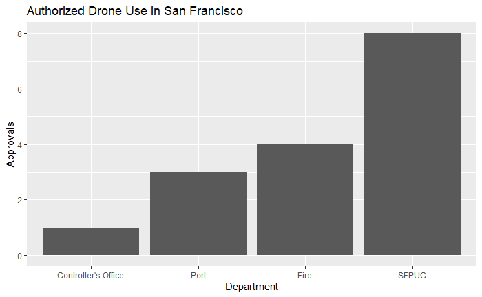

```r
drones_tbl %>%
  group_by(department) %>%
  summarise(department_approvals = n()) %>%
  ggplot(
    aes(x = reorder(department, department_approvals),
        y = department_approvals)) +
  geom_bar(stat = "identity") +
  labs(title = "Authorized Drone Use in San Francisco",
       x     = "Department",
       y     = "Approvals")
```

3. How does the Fire department propose to use drones; hint: display the information in the ‘drone_descriptive_title’.

```r
drones_tbl %>%
  filter(department == "Fire") %>%
  select(department,
         drone_descriptive_title)
```

| department | drone_descriptive_title |
| --- | --- |
| Fire | Disaster Response: Assessment and District Surveys |
| Fire | Training: Assessment, Evaluation & Proficiency |
| Fire | Building Fire Reconnaissance |
| Fire | Aerial or water borne drones |

## Question 4 - Answer the following questions using the Ratio Of Female To Male Youth Unemployment Rate from the World bank.

1. Load both csv files in your R script:
1. Store API_SL.UEM.1524.FM.ZS_DS14_en_csv_v2_1014165.csv into a dataframe called yearly_indicator_data. b. Store Metadata_Country_API_SL.UEM.1524.FM.ZS_DS14_en_csv_v2_1014165.csv into a dataframe called country_metadata.

```r
yearly_indicator_data <-
  read_csv("API_SL.UEM.1524.FM.ZS_DS14_en_csv_v2_1121011/API_SL.UEM.1524.FM.ZS_DS14_en_csv_v2_1121011.csv",
           skip = 4)
country_metadata <-
  read_csv("API_SL.UEM.1524.FM.ZS_DS14_en_csv_v2_1121011/Metadata_Country_API_SL.UEM.1524.FM.ZS_DS14_en_csv_v2_1121011.csv")
```

2. Perform steps to tidy yearly_indicator_data; use spread(), gather() and separate() where applicable; ensure that both yearly_indicator_data and country_metadata are represented as tibbles

```r
yearly_indicator_data_1<-
  yearly_indicator_data %>%
        pivot_longer(cols      = as.character(1960:2020),
                     names_to  = "year",
                     values_to = "ratio") %>%             ## gather year columns
        select(-one_of("X66",
                       "Country Code",
                       "Indicator Name",
                       "Indicator Code")) %>%             ## exclude redundant information
    rename(ratio_SL.UEM.1524.FM.ZS = ratio) %>%           ## make colname more informative
      drop_na()                                           ## exclude NAs
yearly_indicator_data_1
```

| Country Name | year | ratio_SL.UEM.1524.FM.ZS |
| --- | --- | --- |
| Afghanistan | 1991 | 131.47709 |
| Afghanistan | 1992 | 131.39884 |
| Afghanistan | 1993 | 130.19326 |
| Afghanistan | 1994 | 131.05138 |
| Afghanistan | 1995 | 133.25726 |
| Afghanistan | 1996 | 130.93094 |
| Afghanistan | 1997 | 133.02144 |
| Afghanistan | 1998 | 133.26536 |
| Afghanistan | 1999 | 133.21368 |
| Afghanistan | 2000 | 132.95054 |

[output cut: 990 more lines]

```r
country_metadata %>%
  select(-one_of("Country Code", "X6")) %>%  ## remove redundant cols
  drop_na(Region, IncomeGroup)               ## drop rows with NAs only in Region or IncomeGroup
```

| Region | IncomeGroup | SpecialNotes | TableName |
| --- | --- | --- | --- |
| Latin America & Caribbean | High income | NA | Aruba |
| South Asia | Low income | NA | Afghanistan |
| Sub-Saharan Africa | Lower middle income | NA | Angola |
| Europe & Central Asia | Upper middle income | NA | Albania |
| Europe & Central Asia | High income | NA | Andorra |
| Middle East & North Africa | High income | NA | United Arab Emirates |
| Latin America & Caribbean | Upper middle income | NA | Argentina |
| Europe & Central Asia | Upper middle income | NA | Armenia |
| East Asia & Pacific | Upper middle income | NA | American Samoa |
| Latin America & Caribbean | High income | NA | Antigua and Barbuda |

[output cut: 207 more lines]

3. Display the dimensions of yearly_indicator_data and country_metadata.

```r
dim(yearly_indicator_data)
```

```
[1] 263  66
```

```r
dim(country_metadata)
```

```
[1] 263   6
```

4. Create a new tibble with: the Country Name, Country Code, Region and IncomeGroup. Give the new dataset an appropriate name.

```r
country_metadata_1 <-
    country_metadata %>%
      select(-one_of("X6", "SpecialNotes")) %>%   ## remove unneeded cols
  rename(CountryName = TableName)                 ## more meaningful name

country_metadata_1
```

| Country Code | Region | IncomeGroup | CountryName |
| --- | --- | --- | --- |
| ABW | Latin America & Caribbean | High income | Aruba |
| AFG | South Asia | Low income | Afghanistan |
| AGO | Sub-Saharan Africa | Lower middle income | Angola |
| ALB | Europe & Central Asia | Upper middle income | Albania |
| AND | Europe & Central Asia | High income | Andorra |
| ARB | NA | NA | Arab World |
| ARE | Middle East & North Africa | High income | United Arab Emirates |
| ARG | Latin America & Caribbean | Upper middle income | Argentina |
| ARM | Europe & Central Asia | Upper middle income | Armenia |
| ASM | East Asia & Pacific | Upper middle income | American Samoa |

[output cut: 253 more lines]

5. List the name of high income countries in: Sub-Saharan Africa. Are there supporting data about the Ratio of female to male youth unemployment rate? If there is supporting data, what does the data indicate? If not, what are your recommendations to address this issue?

```r
country_metadata_1 %>%
  filter(Region == "Sub-Saharan Africa",
         IncomeGroup == "High income")
```

| Country Code | Region | IncomeGroup | CountryName |
| --- | --- | --- | --- |
| SYC | Sub-Saharan Africa | High income | Seychelles |

```r
yearly_indicator_data_1 %>%
  filter(`Country Name` == "Seychelles")
```

| Country Name | year | ratio_SL.UEM.1524.FM.ZS |
| --- | --- | --- |

```r
NA
```

There is no supporting data about the ratio of female to male youth unemployment rate for high income countries in Sub-Saharan Africa. An alternative way to assess unemployment rate in Sub-Saharan Africa is to observe income groups which are more common to the region.

```r
## find the most common income groups in Sub-Saharan Africa
country_metadata_1 %>%
    filter(Region == "Sub-Saharan Africa") %>%
  group_by(IncomeGroup) %>%
  summarise(count = n()) %>%
  arrange(desc(count))
```

| IncomeGroup | count |
| --- | --- |
| Low income | 24 |
| Lower middle income | 17 |
| Upper middle income | 6 |
| High income | 1 |

```r
## get countries with the most common income group
low_income_SSA_countries <-
  country_metadata_1 %>%
    filter(Region == "Sub-Saharan Africa",
           IncomeGroup == "Low income") %>%
  pull(CountryName)

## Get region-specific SL.UEM.1524.FM.ZS data for Sub-Saharan Africa
yearly_indicator_data_1 %>%
    filter(`Country Name` %in% low_income_SSA_countries) %>%
  group_by(`Country Name`) %>%
  summarise(median_SL.UEM.1524.FM.ZS = median(ratio_SL.UEM.1524.FM.ZS)) %>%
  arrange(desc(median_SL.UEM.1524.FM.ZS))
```

| Country Name | median_SL.UEM.1524.FM.ZS |
| --- | --- |
| Gambia, The | 184.35853 |
| Ethiopia | 173.69588 |
| Liberia | 145.29867 |
| Burkina Faso | 142.83103 |
| Tanzania | 127.86636 |
| Mali | 121.35984 |
| Uganda | 119.74709 |
| Malawi | 115.14321 |
| Togo | 109.54330 |
| Benin | 97.53757 |

[output cut: 14 more lines]

6. Select two high income countries in each of the following regions: North America, Middle East & North Africa, Latin America & Caribbean, Europe & Central Asia and East Asia & Pacific. Display the trend from 1991 to 2019. Use facet_wrap to display the charts by region

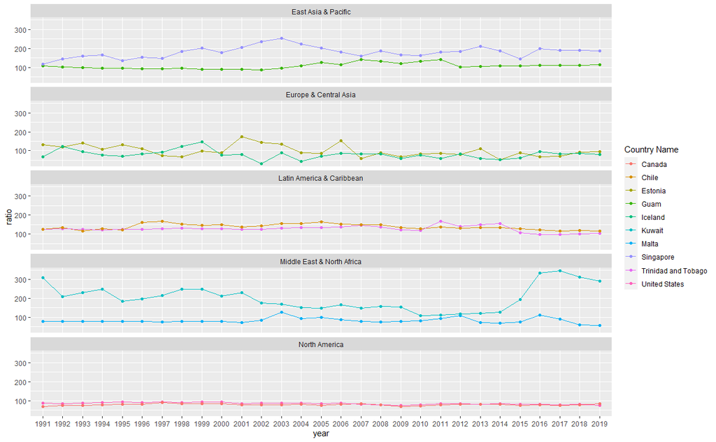

```r
set.seed(123)                                                   ## reproducible sampling
inner_join(country_metadata,
           yearly_indicator_data) %>%                           ## merge tables
  select(-one_of(
    as.character(1960:1990, 2020),
    "SpecialNotes", "TableName", "X6", "X66")) %>%              ## exclude unneeded columns
  filter(IncomeGroup == "High income") %>%                      ## filter high income
  group_by(Region) %>% drop_na() %>% sample_n(2) %>%            ## sample 2 countries per region
  pivot_longer(cols = as.character(1991:2019),
               names_to  = "year", values_to = "ratio") %>%     ## gather columns
  ggplot(aes(x     = year,
             y     = ratio,
             color = `Country Name`,
             group = `Country Name`)) +
    geom_line() + geom_point() +
    facet_wrap(~Region, ncol = 1)
```

1. Summarize your observations: what does the data indicate about the ratio of female to male youth unemployment rate in the selected regions.

This data is showing that the ratio of female to male youth unemployment rate varies significantly among different regions even in the same income class. In North and Latin America, the rate has remained relatively constant from 1991 to 2019, but countries in the Middle East and East Asia experience more fluctuations over time. The two countries selected for the Middle East (Malta and Kuwait) show significantly different ratios over time with the unemployment ratio in Kuwait far exceeding any other high income countries. A larger sample set than n = 2 would be needed to make a conclusion about countries in the Middle East region.